# Lecture 7. Data Formatting

Zechariah Meunier

2025-04-21

## Data Types and Structures

Generally, data exist in two main types, each of which has three sub-types:

- **Qualitative**: categorical data
  - Nominal data are names that cannot be ordered (e.g., country names)
  - Ordinal data are names that can be ordered (e.g., insect life stages)
  - Boolean data are names for logical outcomes (e.g., true or false)
- **Quantitative**: numerical data
  - Discrete (integer) data are numerical and cannot be divided (e.g., turkey abundance)
  - Continuous (ratio) data are numerical and can be divided (e.g., transect distance)
  - Complex data are numerical and include imaginary numbers (e.g., $3 + 2i$)

In R and other programming languages, these general data types map onto specific data types with some additional types.

| General Data Type | R Data Type |
| --- | --- |
| Nominal | Character |
| Ordinal | Factor |
| Boolean | Logical |
| Discrete | Numeric, integer |
| Continuous | Numeric, double |
| Complex | Numeric, complex |
| NA | Date |

We can determine the data type, or object class, of data using the `class` function.

```r
a <- "7"
class(a)
```

```
## [1] "character"
```

```r
b <- factor("7")
class(b)
```

```
## [1] "factor"
```

```r
c <- TRUE
class(c)
```

```
## [1] "logical"
```

```r
d <- 7L
class(d)
```

```
## [1] "integer"
```

```r
e <- 7.0
class(e)
```

```
## [1] "numeric"
```

```r
f <- 3 + 2i
class(f)
```

```
## [1] "complex"
```

There are also several kinds of data structures (sometimes called structs), which organize and store data in specific ways. Data structures are organized into two main types, each of which has several sub-types:

- **Primitive**: basic data structures do not contain any additional methods or properties
  - Integers
  - Floating point numbers (sometimes called floats), which are limited precision continuous numbers
  - Characters
  - Booleans
- **Non-primitive**: complex data structures contain more information, often organized in rows and columns with dimensions given as rows $\times$ columns
  - Vector: one-dimensional structure ($1 \times n$ or $n \times 1$) where all the elements must be the same type
    - When $n=1$ it is called a scalar
  - Matrix: two-dimensional structure ($m \times n$) with one data type for all columns
  - Array: multidimensional structure ($m \times n \times o \times \cdot \cdot \cdot$) with one data type for all matrices
  - Data frame: two-dimensional structure ($m \times n$) where each column is the same length but can differ in data type
    - A typical data table
  - List: any dimensional structure that can contain multiple data types

Let’s take a look at some example data structures.

```r
w <- c("a","b","c","d","e","f")
w
```

```
## [1] "a" "b" "c" "d" "e" "f"
```

```r
class(w)
```

```
## [1] "character"
```

```r
x <- c(a,b,c,d,e,f)
x
```

```
## [1] "7"    "1"    "TRUE" "7"    "7"    "3+2i"
```

```r
class(x)
```

```
## [1] "character"
```

```r
y <- matrix(data = c(w,x), nrow = 6, ncol = 2)
y
```

```
##      [,1] [,2]
## [1,] "a"  "7"
## [2,] "b"  "1"
## [3,] "c"  "TRUE"
## [4,] "d"  "7"
## [5,] "e"  "7"
## [6,] "f"  "3+2i"
```

```r
class(y)
```

```
## [1] "matrix" "array"
```

```r
z <- data.frame(col1 = w, col2 = x)
z
```

```
##   col1 col2
## 1    a    7
## 2    b    1
## 3    c TRUE
## 4    d    7
## 5    e    7
## 6    f 3+2i
```

```r
class(z)
```

```
## [1] "data.frame"
```

## Coral Reef Case Study

### Data Formatting

Today we’ll be formatting data from the Australian Institute of Marine Science (AIMS) Long-term Monitoring Program (LTMP) for benthic cover of hard coral, soft coral, algae, and other organisms on the Great Barrier Reef.

First, read in the data, then look at the first few rows.

```r
aims <- read.csv("ltmp_hc_sc_a_by_site_1992_2022.csv")
head(aims)
```

```
##   SECTOR SHELF        REEF_NAME REEF_ID SITE_NO  LATITUDE LONGITUDE VISIT_NO
## 1     CA     I LOW ISLANDS REEF  16028S       1 -16.38352  145.5710        1
## 2     CA     I LOW ISLANDS REEF  16028S       1 -16.38352  145.5710        1
## 3     CA     I LOW ISLANDS REEF  16028S       1 -16.38352  145.5710        1
## 4     CA     I LOW ISLANDS REEF  16028S       1 -16.38352  145.5710        1
## 5     CA     I LOW ISLANDS REEF  16028S       2 -16.38648  145.5726        1
## 6     CA     I LOW ISLANDS REEF  16028S       2 -16.38648  145.5726        1
##   YEAR_CODE SAMPLE_DATE GROUP_CODE COVER
## 1    199293  1993-06-12      Algae 30.64
## 2    199293  1993-06-12 Hard Coral 24.77
## 3    199293  1993-06-12      Other 26.78
## 4    199293  1993-06-12 Soft Coral 17.82
## 5    199293  1993-06-12      Algae 35.83
## 6    199293  1993-06-12 Hard Coral 29.91
```

What kind of data structure is this? Do all of the columns have the appropriate data type?

```r
class(aims$SECTOR)
```

```
## [1] "character"
```

```r
class(aims$SHELF)
```

```
## [1] "character"
```

```r
class(aims$REEF_NAME)
```

```
## [1] "character"
```

```r
class(aims$REEF_ID)
```

```
## [1] "character"
```

```r
class(aims$SITE_NO)
```

```
## [1] "integer"
```

```r
class(aims$LATITUDE)
```

```
## [1] "numeric"
```

```r
class(aims$LONGITUDE)
```

```
## [1] "numeric"
```

```r
class(aims$VISIT_NO)
```

```
## [1] "integer"
```

```r
class(aims$YEAR_CODE)
```

```
## [1] "integer"
```

```r
class(aims$SAMPLE_DATE)
```

```
## [1] "character"
```

```r
class(aims$GROUP_CODE)
```

```
## [1] "character"
```

```r
class(aims$COVER)
```

```
## [1] "numeric"
```

A couple of these columns have incorrect data types, specifically character instead of factor or date. For example, let’s convert the column that stores the sample date to a date data type.

```r
aims$SAMPLE_DATE <- as.Date(aims$SAMPLE_DATE, format = "%Y-%m-%d")
class(aims$SAMPLE_DATE)
```

```
## [1] "Date"
```

Next, let’s change the column `SECTOR` to a factor with the individual sectors ordered from north to south. We’ll use the `unique` function to look at the values of the sectors, which are two-letter abbreviations for the sectors described in the metadata.

```r
unique(aims$SECTOR)
```

```
##  [1] "CA" "CB" "CG" "CL" "IN" "PC" "PO" "SW" "TO" "WH"
```

To determine the north-south orientation of these sectors, let’s leverage the GPS coordinates in the columns `LONGITUDE` and `LATITUDE` as x and y coordinates on a simple map.

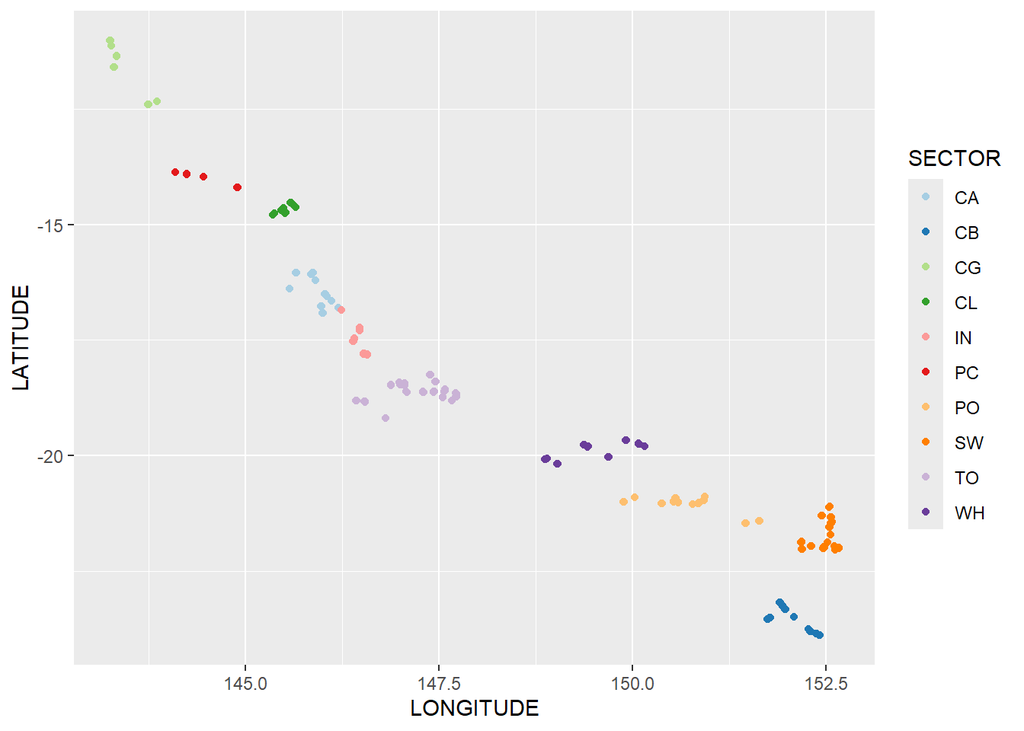

```r
library(ggplot2)
ggplot(data = aims, aes(x = LONGITUDE, y = LATITUDE, color = SECTOR)) +
  geom_point() +
  scale_color_brewer(palette = "Paired")
```

We can double-check our values by referencing the AIMS LTMP map showing the sectors and regions.

[AIMS LTMP map](https://www.aims.gov.au/information-centre/news-and-stories/initial-great-barrier-reef-monitoring-results-show-coral-mortality-north-due-bleaching-and-cyclones)

If everything looks correct, let’s set `SECTOR` as a factor with the levels arranged north-south.

```r
aims$SECTOR <- factor(aims$SECTOR,
                      levels = c("CG","PC","CL","CA","IN",
                                 "TO","WH","PO","SW","CB"))
unique(aims$SECTOR)
```

```
##  [1] CA CB CG CL IN PC PO SW TO WH
## Levels: CG PC CL CA IN TO WH PO SW CB
```

Notice how the map also groups the sectors into three regions on the Great Barrier Reef: Northern, Central, and Southern. We want to add a new column to our data frame containing the information for region.

There are a few ways to accomplish this. First, we could create a new data frame and perform a join operation using `left_join` from the `dplyr` package.

```r
library(dplyr)
Regions <- data.frame(REGION = c("Northern","Northern","Northern",
                                 "Central","Central","Central","Central",
                                 "Southern","Southern","Southern"),
                      SECTOR = levels(aims$SECTOR))

aims2 <- left_join(aims, Regions, by = "SECTOR")
```

Second, we could use `mutate` and `case_match` functions on the original data frame.

```r
aims <- aims %>%
  mutate(REGION = case_match(SECTOR,
                            "CG" ~ "Northern",
                            "PC" ~ "Northern",
                            "CL" ~ "Northern",
                            "CA" ~ "Central",
                            "IN" ~ "Central",
                            "TO" ~ "Central",
                            "WH" ~ "Central",
                            "PO" ~ "Southern",
                            "SW" ~ "Southern",
                            "CB" ~ "Southern"))
```

Third, we could use nested `if_else` statements, but that’s too much work. Consider that we also want our new column to be formatted as a factor variable.

```r
aims$REGION <- factor(aims$REGION,
                      levels = c("Northern","Central","Southern"))
```

Let’s refine our map with this new information. We’ll add the outline of the continent of Australia from the `rnaturalearth` package.

```r
library(sf)
library(rnaturalearth)
library(rnaturalearthdata)
```

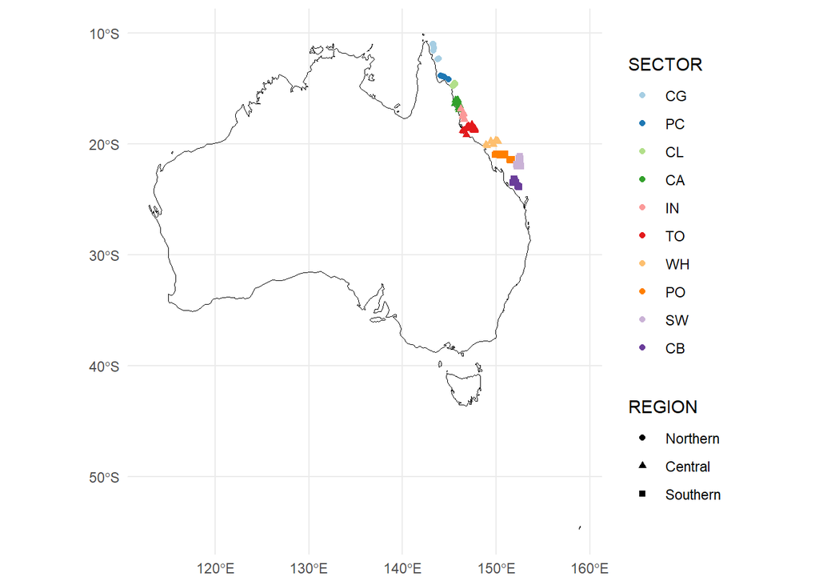

```r
australia <- ne_countries(scale = "medium", country = "Australia", returnclass = "sf")

aims_sf <- aims %>%
  st_as_sf(coords = c("LONGITUDE", "LATITUDE"), crs = 4326)

ggplot() +
  geom_sf(data = australia, fill = NA, color = "black") +
  geom_sf(data = aims_sf, aes(color = SECTOR, shape = REGION)) +
  scale_color_brewer(palette = "Paired") +
  theme_minimal()
```

One more column needs additional scrutiny: `SHELF`. This shows the location of individual reefs in reference to the mainland as `I` for inshore, `M` for mid-shelf, and `O` for outer shelf or offshore. These could also be ordered from proximal to distal to land, so we’ll convert `SHELF` to a factor as well.

```r
aims$SHELF <- factor(aims$SHELF,
                     levels = c("I","M","O"))
```

### Research Questions

Now let’s learn something from this massive data set! We’ll investigate the following questions:

1. How does cover of coral and algae differ among regions of the Great Barrier Reef in recent years?
2. How has coral cover changed over time?
3. Does the distance of the reef to the mainland matter for healthy coral populations?

#### Question 1

To see the most recent sampling year with all regions surveyed, use the `table` function. Here, we’re also using `year` from the package `lubridate`.

```r
library(lubridate)
table(year(aims$SAMPLE_DATE),aims$REGION)
```

```
##
##        Northern Central Southern
##   1992        0     132      108
##   1993      120     168        0
##   1994       96     156      192
##   1995       96     324      132
##   1996       84     324      132
##   1997      108     324      132
##   1998       96     336      132
##   1999       96     336      132
##   2000       96     336      132
##   2001       96     552      132
##   2002       96     336      132
##   2003       96     108      132
##   2004       96     336      132
```

[output cut: 18 more lines]

Let’s go ahead and add a `YEAR` column to our dataset, since the current `YEAR_CODE` isn’t very meaningful.

```r
aims$YEAR <- year(aims$SAMPLE_DATE)
```

For simplicity, we’ll look at a boxplot of coral cover from 2021.

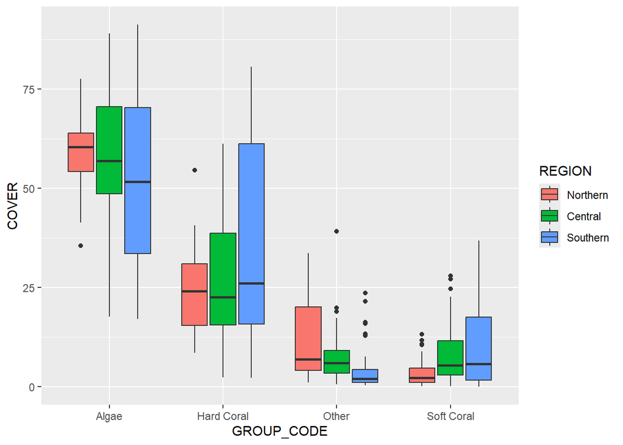

```r
ggplot(data = filter(aims, YEAR == 2021),
       aes(x = GROUP_CODE, y = COVER, fill = REGION)) +
  geom_boxplot()
```

To see how this comparison depends on the year, let’s use a new function called `facet_wrap`, which makes individual panels faceted by a variable of interest, in this case `YEAR`.

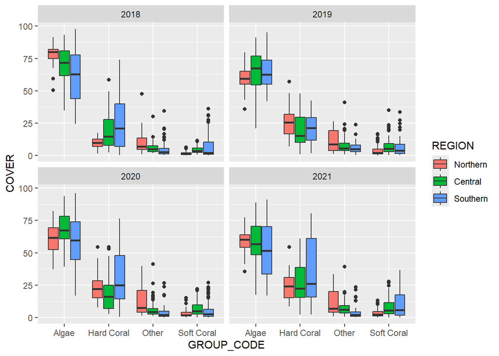

```r
ggplot(data = filter(aims, YEAR %in% c(2018, 2019, 2020, 2021)),
       aes(x = GROUP_CODE, y = COVER, fill = REGION)) +
  geom_boxplot() +
  facet_wrap(~YEAR)
```

So what’s the answer to our first research question: How does cover of coral and algae differ among regions of the Great Barrier Reef in recent years?

#### Question 2

Time series data are best displayed in line graphs, so let’s adjust our figure accordingly. We’ll summarize the data as means and 95% confidence intervals using the `stat_summary` function and make several alterations to the figure to improve its quality.

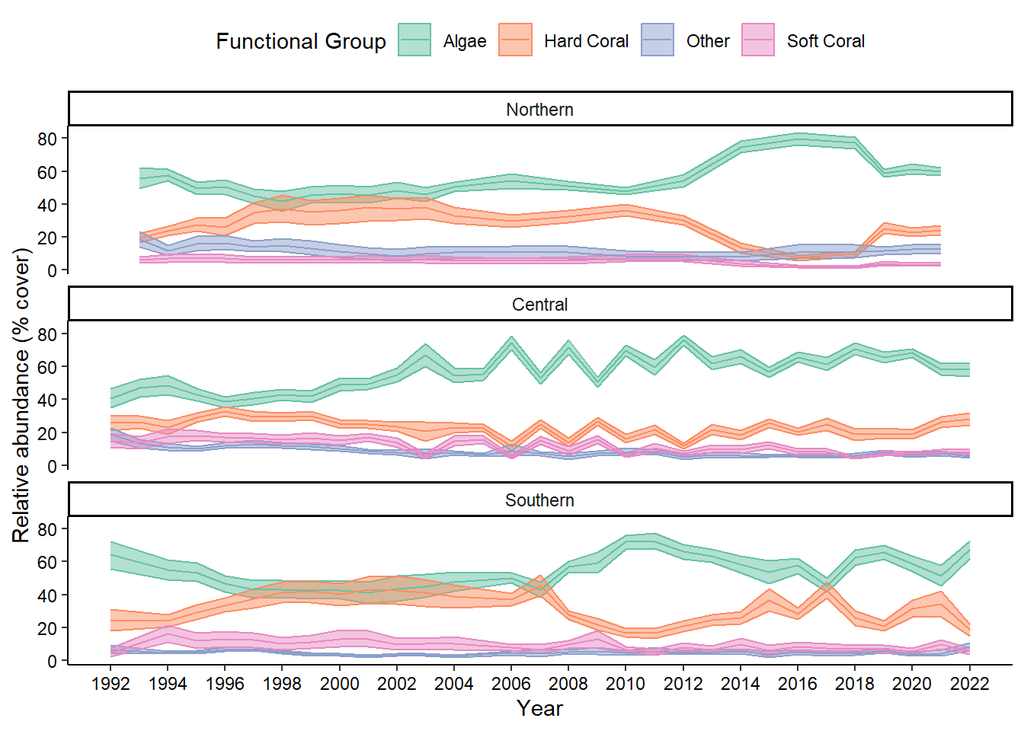

```r
ggplot(data = aims, aes(x = YEAR, y = COVER, color = GROUP_CODE, fill = GROUP_CODE)) +
  stat_summary(fun.data = "mean_cl_boot", geom = "ribbon", alpha = 0.5) +
  stat_summary(fun = "mean", geom = "line") +
  scale_x_continuous(name = "Year", breaks = seq(1992,2022,2)) +
  scale_y_continuous(name = "Relative abundance (% cover)", breaks = seq(0,100,20)) +
  scale_color_brewer(name = "Functional Group", palette = "Set2") +
  scale_fill_brewer(name = "Functional Group", palette = "Set2") +
  facet_wrap(~REGION, nrow = 3, ncol = 1) +
  theme_classic() +
  theme(legend.position = "top",
        axis.text = element_text(color = "black"))
```

So what’s the answer to our second research question: How has coral cover changed over time?

#### Question 3

Moving on to our third research question, we want to evaluate the effects of distance to the mainland. While we could calculate a continuous value for distance, we’ll instead leverage the factor we created earlier, `SHELF`. We’ll change `facet_wrap` to `facet_grid`, which allows us to use an additional variable in our panels.

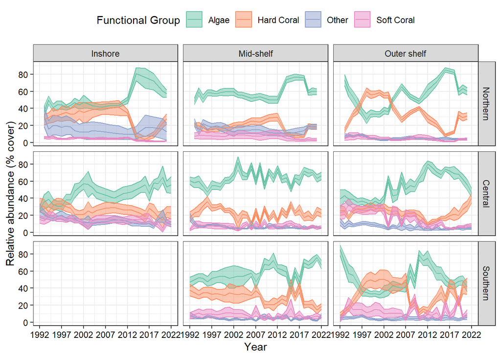

```r
ggplot(data = aims, aes(x = YEAR, y = COVER, color = GROUP_CODE, fill = GROUP_CODE)) +
  stat_summary(fun.data = "mean_cl_boot", geom = "ribbon", alpha = 0.5) +
  stat_summary(fun = "mean", geom = "line") +
  scale_x_continuous(name = "Year", breaks = seq(1992,2022,5)) +
  scale_y_continuous(name = "Relative abundance (% cover)", breaks = seq(0,100,20)) +
  scale_color_brewer(name = "Functional Group", palette = "Set2") +
  scale_fill_brewer(name = "Functional Group", palette = "Set2") +
  facet_grid(rows = vars(REGION), cols = vars(SHELF),
             labeller = labeller(SHELF = c("I"="Inshore",
                                           "M"="Mid-shelf",
                                           "O"="Outer shelf"))) +
  theme_bw() +
  theme(legend.position = "top",
        axis.text = element_text(color = "black"))
```

So what’s the answer to our third research question: Does the distance of the reef to the mainland matter for healthy coral populations?